# Group_2_RMED901-R

Group 2 members

2022-09-23

###Description of data set: Source: This data set is mainly from Cata et al. ’Blood Storage Duration and Biochemical Recurrence of Cancer after Radical Prostate- ctomy’. Mayo Clin Proc 2011; 86(2): 120-127. This data set contains data on 316 men who had undergone radical prostatectomy and received transfusion during or within 30 days of the surgical procedure and had available prostate serum antigen (PSA) follow-up data. The main exposure of interest was RBC storage duration group. The dataset has been transformed by the teachers so that it is not in the tidy format anymore.In other words, the txt-file *exam_nontidy.txt* contains a large dataset of many variables and a large number of observations.

####***Day5: Exploring data. We used glimpse function to check if any column starts with a number or has any spaces. Also it was possible to check the first and last few columns. We also inspected the dataset to check if there are any columns contained combined variables, which need to be in separate columns. In additipn,we checked if there are any missing values.

```r
library(tidyverse)
library(here)
data<-read_delim (here("groupproject", "exam_nontidy.txt"))
glimpse(data)
```

```
## Rows: 672
## Columns: 21
## $ subject               <chr> "Hosp2-179", "Hosp2-179", "Hosp1-14", "Hosp1-14"~
## $ RBC.Age.Group         <dbl> 1, 1, 1, 1, 3, 3, 2, 2, 2, 2, 2, 2, 3, 3, 1, 1, ~
## $ Median.RBC.Age        <dbl> 10, 10, 10, 10, 25, 25, 15, 15, 15, 15, 15, 15, ~
## $ `1_Age`               <dbl> 57.0, 57.0, 73.3, 73.3, 64.2, 64.2, 66.9, 66.9, ~
## $ AA                    <dbl> 0, 0, 0, 0, 0, 0, 1, 1, 0, 0, 0, 0, 0, 0, 0, 0, ~
## $ FamHx                 <dbl> 0, 0, 0, 0, 0, 0, 0, 0, 1, 1, 0, 0, 0, 0, 0, 0, ~
## $ `T stage`             <dbl> 1, 1, 2, 2, 1, 1, 1, 1, 1, 1, 2, 2, 1, 1, 1, 1, ~
## $ bGS                   <dbl> 1, 1, 2, 2, 1, 1, 1, 1, 3, 3, 3, 3, 1, 1, 1, 1, ~
## $ `BN+`                 <dbl> 0, 0, 0, 0, 0, 0, 0, 0, 0, 0, 1, 1, 0, 0, 0, 0, ~
## $ OrganConfined         <dbl> 1, 1, 0, 0, 1, 1, 0, 0, 1, 1, 0, 0, 1, 1, 1, 1, ~
## $ PreopPSA              <dbl> 5.10, 5.10, 30.60, 30.60, 5.70, 5.70, 7.50, 7.50~
## $ PreopTherapy          <dbl> 0, 0, 1, 1, 0, 0, 0, 0, 0, 0, 0, 0, 0, 0, 0, 0, ~
## $ Units                 <dbl> 2, 2, 4, 4, 2, 2, 2, 2, 2, 2, 2, 2, 1, 1, 2, 2, ~
## $ AnyAdjTherapy         <dbl> 0, 0, 0, 0, 0, 0, 0, 0, 0, 0, 0, 0, 0, 0, 0, 0, ~
## $ AdjRadTherapy         <dbl> 0, 0, 0, 0, 0, 0, 0, 0, 0, 0, 0, 0, 0, 0, 0, 0, ~
## $ Recurrence            <dbl> 0, 0, 0, 0, 0, 0, 0, 0, 1, 1, 1, 1, 0, 0, 0, 0, ~
## $ Censor                <dbl> 1, 1, 1, 1, 1, 1, 1, 1, 0, 0, 0, 0, 1, 1, 1, 1, ~
## $ TimeToRecurrence      <dbl> 39.03, 39.03, 10.77, 10.77, 50.77, 50.77, 55.53,~
## $ TimeToRecurrence_unit <chr> "week", "week", "week", "week", "week", "week", ~
## $ `volume measurement`  <chr> "PVol", "TVol", "PVol", "TVol", "PVol", "TVol", ~
## $ .value                <dbl> 41.2, 1.0, 38.6, 2.0, 60.0, 2.0, 56.6, 2.0, 52.0~
```

```r
head(data)
```

```
## # A tibble: 6 x 21
##   subject RBC.Age.Group Median.RBC.Age `1_Age`    AA FamHx `T stage`   bGS `BN+`
##   <chr>           <dbl>          <dbl>   <dbl> <dbl> <dbl>     <dbl> <dbl> <dbl>
## 1 Hosp2-~             1             10    57       0     0         1     1     0
## 2 Hosp2-~             1             10    57       0     0         1     1     0
## 3 Hosp1-~             1             10    73.3     0     0         2     2     0
## 4 Hosp1-~             1             10    73.3     0     0         2     2     0
## 5 Hosp3-~             3             25    64.2     0     0         1     1     0
## 6 Hosp3-~             3             25    64.2     0     0         1     1     0
## # ... with 12 more variables: OrganConfined <dbl>, PreopPSA <dbl>,
## #   PreopTherapy <dbl>, Units <dbl>, AnyAdjTherapy <dbl>, AdjRadTherapy <dbl>,
## #   Recurrence <dbl>, Censor <dbl>, TimeToRecurrence <dbl>,
## #   TimeToRecurrence_unit <chr>, `volume measurement` <chr>, .value <dbl>
```

```r
tail(data)
```

```
## # A tibble: 6 x 21
##   subject RBC.Age.Group Median.RBC.Age `1_Age`    AA FamHx `T stage`   bGS `BN+`
##   <chr>           <dbl>          <dbl>   <dbl> <dbl> <dbl>     <dbl> <dbl> <dbl>
## 1 Hosp2-~             1             10    69.8     0     1         2     2     0
## 2 Hosp2-~             1             10    69.8     0     1         2     2     0
## 3 Hosp2-~             3             25    67.1     0     0         1     2     0
## 4 Hosp2-~             3             25    67.1     0     0         1     2     0
## 5 Hosp3-~             1             10    54.8     0     0         1     1     0
## 6 Hosp3-~             1             10    54.8     0     0         1     1     0
## # ... with 12 more variables: OrganConfined <dbl>, PreopPSA <dbl>,
## #   PreopTherapy <dbl>, Units <dbl>, AnyAdjTherapy <dbl>, AdjRadTherapy <dbl>,
## #   Recurrence <dbl>, Censor <dbl>, TimeToRecurrence <dbl>,
## #   TimeToRecurrence_unit <chr>, `volume measurement` <chr>, .value <dbl>
```

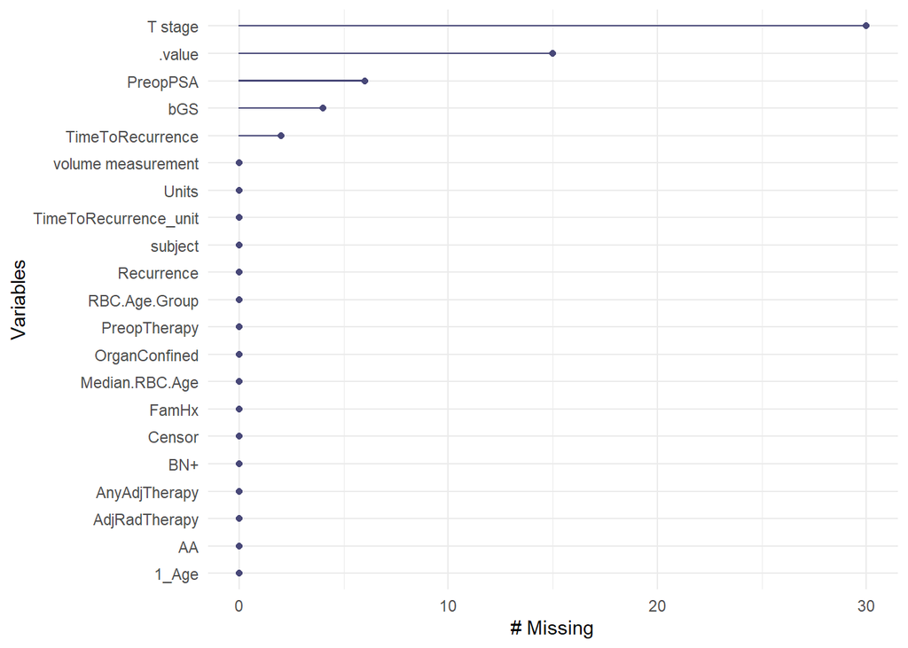

```r
naniar::gg_miss_var(data)
```

```r
  colSums(is.na(data))
```

```
##               subject         RBC.Age.Group        Median.RBC.Age
##                     0                     0                     0
##                 1_Age                    AA                 FamHx
##                     0                     0                     0
##               T stage                   bGS                   BN+
##                    30                     4                     0
##         OrganConfined              PreopPSA          PreopTherapy
##                     0                     6                     0
##                 Units         AnyAdjTherapy         AdjRadTherapy
##                     0                     0                     0
##            Recurrence                Censor      TimeToRecurrence
##                     0                     0                     2
## TimeToRecurrence_unit    volume measurement                .value
##                     0                     0                    15
```

#### *Day6:Tidy, adjust, and explore data*

After exploring the dataset, we removed the duplicates as well as unnecessary columns according to the points mentioned in the exam description. In addition, we made necessary changes in variable types. we wrote a code that breaks up ‘subject’ column into two variables Hospitalname (chategirical) and id (numeric).Subsequently, we renamed some columns that had long names, space between characters, or started with a number.

```r
data<-
data %>%
  distinct() %>%

  select(-AA, -bGS, -`BN+`,-OrganConfined) %>%


  rename(volmx=`volume measurement`,
         value=.value,
         age=`1_Age`,
         t_stage=`T stage`) %>%


  separate(col = subject,
           into = c("Hospitalname", "id"),
           sep = "-")
```

#### *Creating a new set of columns*

According to the exam description, we created a column showing whether PVol is higher than 100 or not. First, we made separate columns for PVol and TVol. Then, we created a new column called “PVol-binary” that shows values as high and low, depending on whether they are higher than 100 or not. The new column shows values as High/Low.

In the next step, we created a numeric column showing TimeToReccurence as days. Then, we removed the old TimeToRecurrence columns since they are now unnecessary. Additionally, we created a column showing the Recurrence as Yes/No. Finally, we added a numeric column showing multiplication of AnyAdjTherapy and PreopTherapy for each person.

```r
data<-
data %>%
  pivot_wider(names_from = volmx,
              values_from =value) %>%


  mutate(pvol_binary=if_else(PVol>100, "High", "Low")) %>%


  mutate(TimeToRecurrence_days=if_else(TimeToRecurrence_unit=="week", (TimeToRecurrence*7), TimeToRecurrence)) %>%


  select(-TimeToRecurrence, -TimeToRecurrence_unit) %>%


      mutate(Recurrence=if_else(Recurrence==0, "NO", "Yes")) %>%



   mutate(PreopAdjTherapy=AnyAdjTherapy*PreopTherapy)
```

# Tidying data

```r
#Set the order of columns as: id, hospital, Age and other columns
data<- data %>%
  select(id, Hospitalname, age, everything())
```

Arrange ID column of your dataset in order of increasing number or alphabetically.

```r
 data<-
   data %>%
   arrange(id)
```

Read and join the additional dataset to your main dataset. change id in orginal data to ‘double’(id in the original data and the merge data need to be the same type) Reading the second dataset and calling it data2 Join new data to original data

```r
  data<-
    data %>%
      mutate(id = as.numeric(id))

  data2<-
  read_delim(here("groupproject", "exam_joindata.txt"))
  data<-
    data %>%
        full_join(data2, by = "id")
```

Exploring the data, checking the number of missing values in each columns

```r
colSums(is.na(data))
```

```
##                    id          Hospitalname                   age
##                     0                     0                     0
##         RBC.Age.Group        Median.RBC.Age                 FamHx
##                     0                     0                     0
##               t_stage              PreopPSA          PreopTherapy
##                    13                     3                     0
##                 Units         AnyAdjTherapy         AdjRadTherapy
##                     0                     0                     0
##            Recurrence                Censor                  PVol
##                     0                     0                     9
##                  TVol           pvol_binary TimeToRecurrence_days
##                     6                     9                     1
##       PreopAdjTherapy                   sGS
##                     0                   116
```

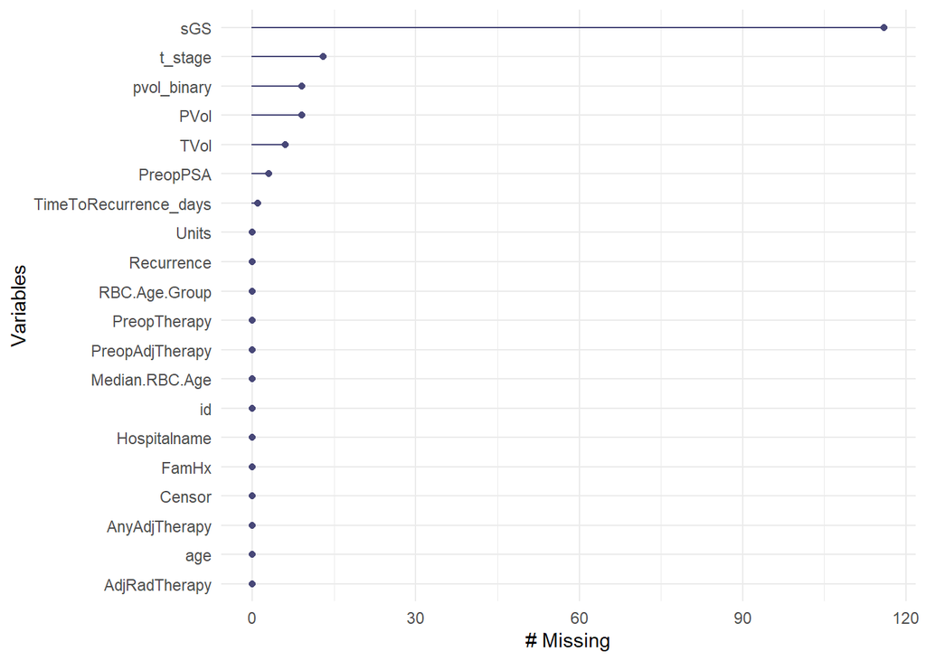

```r
naniar::gg_miss_var(data)
```

```r
names(which(colSums(is.na(data))>0))
```

```
## [1] "t_stage"               "PreopPSA"              "PVol"
## [4] "TVol"                  "pvol_binary"           "TimeToRecurrence_days"
## [7] "sGS"
```

Answer: most of the missing values are in the second data set in SGs values. 116 values for sGS are missing. Whereas in the initial dataset there are some missing values are in t_stage, PVol and TVol but these are quite small in number.

##Stratify your data by a categorical column and report min, max, mean and sd of a numeric column.

Stratify by Recurrence (categorical) and summarizing age (numeric)

```r
recurrence_age <- data %>%
    group_by(Recurrence) %>%
    summarise(max(age, na.rm = T),
      min(age, na.rm = T),
      mean(age, na.rm = T),
       sd(age, na.rm = T))
recurrence_age
```

```
## # A tibble: 2 x 5
##   Recurrence `max(age, na.r~` `min(age, na.r~` `mean(age, na.~` `sd(age, na.rm~`
##   <chr>                 <dbl>            <dbl>            <dbl>            <dbl>
## 1 NO                     76.9             38.4             61.0             6.95
## 2 Yes                    79               42.5             61.8             8.57
```

##Stratify your data by a categorical column and report min, max, mean and sd of a numeric column for a defined set of observations - use pipe!

Only for persons with T.Stage == 1

```r
recurrence_t_stage<- data %>%
  filter(t_stage ==1) %>%
  group_by(Recurrence) %>%
  summarise(max(age, na.rm = T),
            min(age, na.rm = T),
            mean(age, na.rm = T),
            sd(age, na.rm = T))

recurrence_t_stage
```

```
## # A tibble: 2 x 5
##   Recurrence `max(age, na.r~` `min(age, na.r~` `mean(age, na.~` `sd(age, na.rm~`
##   <chr>                 <dbl>            <dbl>            <dbl>            <dbl>
## 1 NO                     74.9             38.4             60.8             6.95
## 2 Yes                    79               42.5             62.9             8.11
```

Only for persons with Median.RBC.Age == 25

```r
Median.RBC_recurrence<- data %>%

  filter(Median.RBC.Age ==25) %>%
  group_by(Recurrence) %>%
  summarise(max(age, na.rm = T),
            min(age, na.rm = T),
            mean(age, na.rm = T),
            sd(age, na.rm = T))

Median.RBC_recurrence
```

```
## # A tibble: 2 x 5
##   Recurrence `max(age, na.r~` `min(age, na.r~` `mean(age, na.~` `sd(age, na.rm~`
##   <chr>                 <dbl>            <dbl>            <dbl>            <dbl>
## 1 NO                     76.9             38.4             60.3             7.34
## 2 Yes                    73.6             42.5             61.2             9.42
```

Only for persons with TimeToReccurence later than 4 days

```r
day4_recurrence<-data %>%
  filter(TimeToRecurrence_days >4) %>%
  group_by(Recurrence) %>%
  summarise(max(age, na.rm = T),
            min(age, na.rm = T),
            mean(age, na.rm = T),
            sd(age, na.rm = T))

day4_recurrence
```

```
## # A tibble: 2 x 5
##   Recurrence `max(age, na.r~` `min(age, na.r~` `mean(age, na.~` `sd(age, na.rm~`
##   <chr>                 <dbl>            <dbl>            <dbl>            <dbl>
## 1 NO                     76.9             38.4             61.0             6.97
## 2 Yes                    79               42.5             61.8             8.77
```

Only for persons recruited in Hosp1 and Tvol == 2

```r
recurrence_hospital_TVol <- data %>%
  filter(Hospitalname == "Hosp1", TVol==2) %>%
  group_by(Recurrence) %>%
  summarise(max(age, na.rm = T),
            min(age, na.rm = T),
            mean(age, na.rm = T),
            sd(age, na.rm = T))
recurrence_hospital_TVol
```

```
## # A tibble: 2 x 5
##   Recurrence `max(age, na.r~` `min(age, na.r~` `mean(age, na.~` `sd(age, na.rm~`
##   <chr>                 <dbl>            <dbl>            <dbl>            <dbl>
## 1 NO                     74.2             43.6             63.3             6.85
## 2 Yes                    72.1             64.4             68.5             3.87
```

Use two categorical columns in your dataset to create a table (hint: ?count)

```r
data %>%
  count(Recurrence,pvol_binary)
```

```
## # A tibble: 6 x 3
##   Recurrence pvol_binary     n
##   <chr>      <chr>       <int>
## 1 NO         High           13
## 2 NO         Low           242
## 3 NO         <NA>            7
## 4 Yes        High            4
## 5 Yes        Low            48
## 6 Yes        <NA>            2
```

### plot Zahra

*Question:* Does the distribution of PreopPSA depend on t_Stage? *Answer:* Answer:t_stage is a set of discrete values, while PreopPSA has continuous values. therefore, geom_boxplot()was used to visualize the data. Based on the plot, it seems that higher t_stage is accompanied by higher distribution of PreopPSA values.

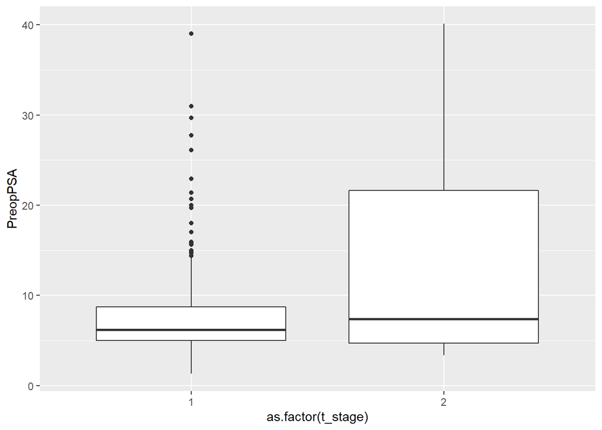

```r
plot1<-
 data %>%
   filter(., !is.na(t_stage)) %>%
   ggplot(data, mapping = aes(x=as.factor(t_stage), y=PreopPSA))+
   geom_boxplot(mapping = NULL, stat = "boxplot", position ="dodge2")
plot1
```

### Plot_Wafa

Deos the distribution of TVol depend on sGS ?

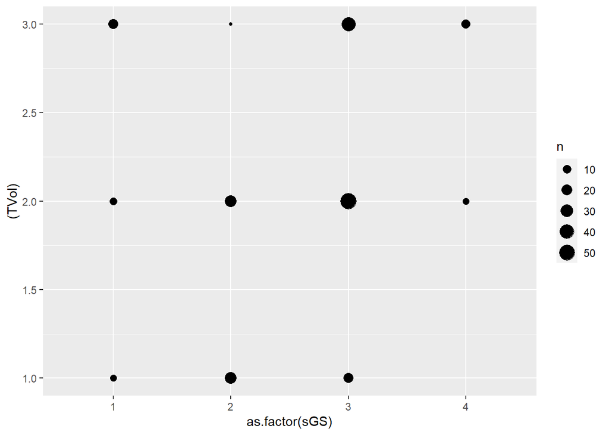

Answer: most of the values of TVol are in sGS at level three and much more so than at sGS values of 1 and 4. So there seems to be some correlation between different values of sGs and TVol.

### plot taraneh

[figure not shown]

```r
ggplot(data = data, aes(x = "PVol", y = "TVol")) +
  geom_point() +
  geom_smooth(method=lm , color="red", fill="#69b3a2", se=TRUE)
```

```r
cor_coefs <- cor.test(data$PVol, data$TVol)
```

## Day 8 Analysis

### Analysis Zahra

Zahra t-test

*Question:* Was the time to recurrence different for various t_Stage levels?

```r
 T_test<-
 data %>%
     t.test(TimeToRecurrence_days~t_stage, data = .) %>%
   broom::tidy()
T_test
```

```
## # A tibble: 1 x 10
##   estimate estimate1 estimate2 statistic p.value parameter conf.low conf.high
##      <dbl>     <dbl>     <dbl>     <dbl>   <dbl>     <dbl>    <dbl>     <dbl>
## 1     96.6      246.      150.      3.22 0.00233      47.9     36.2      157.
## # ... with 2 more variables: method <chr>, alternative <chr>
```

Answer: Since t_stage has 2 categories, I used T.Test to assess the differences between the two categories in terms of the time to recurrence. Based on T.Test, there is a significant difference between various t_stage levels in terms of time to recurrence.

### Analysis_Wafa

Was the time to recurrence different for various RBC.Age.Group levels?

```r
TimetoRecurrencebyRBC_age_group<- data %>%
  mutate(TimeToRecurrence_days=log(TimeToRecurrence_days)) %>%
  aov(TimeToRecurrence_days~RBC.Age.Group, data=.)
TimetoRecurrencebyRBC_age_group
```

```
## Call:
##    aov(formula = TimeToRecurrence_days ~ RBC.Age.Group, data = .)
##
## Terms:
##                 RBC.Age.Group Residuals
## Sum of Squares         0.1835  590.9373
## Deg. of Freedom             1       313
##
## Residual standard error: 1.374037
## Estimated effects may be unbalanced
## 1 observation deleted due to missingness
```

```r
summary(TimetoRecurrencebyRBC_age_group)
```

```
##                Df Sum Sq Mean Sq F value Pr(>F)
## RBC.Age.Group   1    0.2  0.1835   0.097  0.755
## Residuals     313  590.9  1.8880
## 1 observation deleted due to missingness
```

```r
broom::tidy(TimetoRecurrencebyRBC_age_group)
```

```
## # A tibble: 2 x 6
##   term             df   sumsq meansq statistic p.value
##   <chr>         <dbl>   <dbl>  <dbl>     <dbl>   <dbl>
## 1 RBC.Age.Group     1   0.184  0.184    0.0972   0.755
## 2 Residuals       313 591.     1.89    NA       NA
```

Answer to the question: since the p value for Anova is higher than 0.05 it is not possible to reject the null hypothesis and and we cannot claim that the time to recurrence varied by RBC age group